# Part II - (Presentation on the Exploration of Prosper Loan Data )

## by (Osasenaga Oriakhi)

## Investigation Overview

> The main goal of this presentation is to show a few factors that might have contributed to some set of people getting the loans than others and the relationship between the interest rate of the loan and the annual percentage rate.  
> I focus on the category of borrowers that seemed to have been favored in terms of them getting the loan offers.I'll show a barplot that shows that loans were given more to people with incomes that can be verified. I also focus on a few factors that might have contributed to them being favored over others..I'll also be displaying a plot that shows that the set of borrowers that had more people with incomes that could be verified were the employed borrowers.I'll show that these set of borrowers took out larger amounts. Lastly,I show the relationship between the interest rate for the loan and the annual percentage rate with a scatter plot.

## Dataset Overview

> This data set is called the Loan Data from Prosper.It contains 113,937 loans with 81 variables on each loan.It contains details about the borrowers' employment status,whether or not their income can be verified,whether or not they own homes,whether or not they have taken a Prosper loan before,credit score range,occupation,the purpose of the loan, etc.

## (Visualization 1)

> A bar plot that shows the amount of borrowers with income that are verified. Looks like loans were given out more to people who had incomes that could be verified.

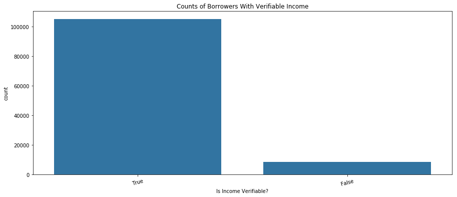

```python
#bar plot to show count of borrowers whose income can be verified
type_order=clean_loan.IncomeVerifiable.value_counts().index
base_color = sb.color_palette()[0]
plt.figure(figsize=(15,6))
sb.countplot(data=clean_loan, x='IncomeVerifiable', color=base_color, order=type_order)
plt.xlabel('Is Income Verifiable?')
plt.ylabel('count')
plt.title('Counts of Borrowers With Verifiable Income')
plt.xticks(rotation=15);
```

## (Visualization 2)

> A plot that displays the monthly income and employment status of borrowers plus whether or not their income can be verified. Employed borrowers have people with incomes that can be verified although, more borrowers that are self employed earned more.

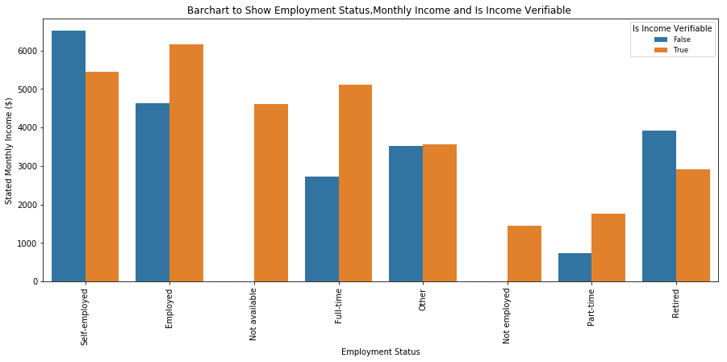

```python
plt.figure(figsize=(15,6))
sb.barplot(data=clean_loan,x='EmploymentStatus', y='StatedMonthlyIncome', ci=None, hue='IncomeVerifiable')
plt.xlabel('Employment Status')
plt.ylabel('Stated Monthly Income ($)')
plt.legend(title="Is Income Verifiable",
                    loc=0, fontsize='small', fancybox=True)
plt.title('Barchart to Show Employment Status,Monthly Income and Is Income Verifiable ')
plt.xticks(rotation=90);
```

## (Visualization 3)

> This chart shows the original amount that was borrowed and their employment status. As suspected, borrowers who are employed were able to take out larger sums compared to others.Followed by borrowers who were self employed.

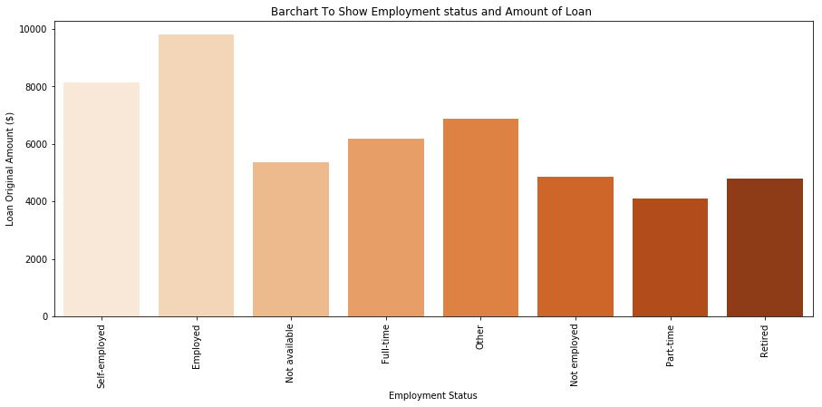

```python
plt.figure(figsize=(15,6))
sb.barplot( x = 'EmploymentStatus', y = 'LoanOriginalAmount', ci=None, data=clean_loan, palette = 'Oranges')
plt.xlabel('Employment Status')
plt.ylabel('Loan Original Amount ($)')
plt.title('Barchart To Show Employment status and Amount of Loan ')
plt.xticks(rotation=90);
```

# Visualisation 4

> This is to show the relationship between the interest rate of loans and the annual percentage rate. There is positive linear correlation between the interest rate and the annual interest rate.

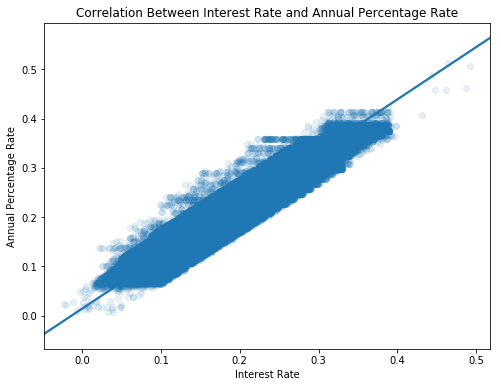

```python
plt.figure(figsize = [8, 6])
sb.regplot(data = clean_loan, x = 'BorrowerRate', y = 'BorrowerAPR',x_jitter=0.04,scatter_kws={'alpha':1/10})
plt.xlabel('Interest Rate')
plt.ylabel('Annual Percentage Rate')
plt.title('Correlation Between Interest Rate and Annual Percentage Rate');
```